# Project 1 EDA: Insurance Charges

MSDS 6372: Jacob Turner

Aaron Powell

2026-09-26

## Introduction and objectives

An insurance provider wants to know whether customer information is associated with the amount charged to health accounts, and whether those associations depend on the customer’s region.

This notebook is EDA only. Rubric requirements covered here: variable table, summary statistics, 4–6 response-vs-predictor graphics, and at least two interaction plots.

```r
ins_raw <- read.csv("../data/insurance.csv", stringsAsFactors = TRUE)

n_miss <- sum(is.na(ins_raw))
n_raw <- nrow(ins_raw)
dup_rows <- ins_raw %>%
  filter(duplicated(.) | duplicated(., fromLast = TRUE))
dup_rows
```

| age | sex | bmi | children | smoker | region | charges |
| --- | --- | --- | --- | --- | --- | --- |
| 19 | male | 30.59 | 0 | no | northwest | 1639.563 |
| 19 | male | 30.59 | 0 | no | northwest | 1639.563 |

```r
ins <- ins_raw %>%
  distinct() %>%
  mutate(
    smoker = factor(smoker, levels = c("no", "yes")),
    region = factor(region, levels = c("northeast", "northwest", "southeast", "southwest")),
    sex = factor(sex, levels = c("female", "male")),
    children_f = factor(children)
  )

n <- nrow(ins)
n_dropped <- n_raw - n
```

Raw file: $n = 1338$ rows, 7 columns, 0 missing cells. One exact duplicate pair (19-year-old male, northwest, non-smoker, `charges = 1639.56`). Drop the extra copy with `distinct()`. Analysis file: $n = 1337$ (1 row removed). No imputation.

## Data description

| Variable | Type | Role | Description |
| --- | --- | --- | --- |
| `age` | numeric | predictor | Customer age in years (18–64) |
| `sex` | factor | predictor | `female` / `male` |
| `bmi` | numeric | predictor | Body mass index |
| `children` | integer | predictor | Number of children (0–5) |
| `smoker` | factor | predictor | `yes` / `no` |
| `region` | factor | predictor | `northeast`, `northwest`, `southeast`, `southwest` |
| `charges` | numeric | **response** | Total charges on the customer’s health account |

Processing: drop the one exact duplicate row; recode factors with explicit levels so plots and later dummy coding are stable. `children` is kept numeric for a linear term and copied as `children_f` for boxplots. No other cleaning. The delivered CSV is left as-is; the drop happens in this notebook.

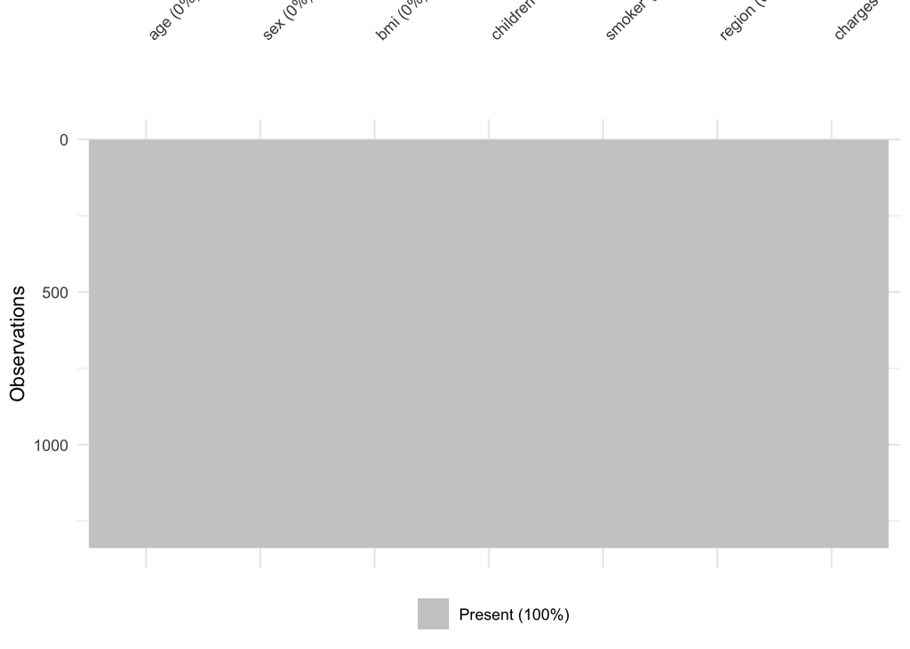

```r
vis_miss(ins_raw)
```

```r
summ_num(ins %>% select(age, bmi, children, charges))
```

| name | n | n_miss | mean | sd | min | q25 | median | q75 | max |
| --- | --- | --- | --- | --- | --- | --- | --- | --- | --- |
| age | 1337 | 0 | 39.222139 | 14.044333 | 18.000 | 27.000 | 39.000 | 51.00 | 64.00 |
| bmi | 1337 | 0 | 30.663452 | 6.100468 | 15.960 | 26.290 | 30.400 | 34.70 | 53.13 |
| charges | 1337 | 0 | 13279.121487 | 12110.359656 | 1121.874 | 4746.344 | 9386.161 | 16657.72 | 63770.43 |
| children | 1337 | 0 | 1.095737 | 1.205571 | 0.000 | 0.000 | 1.000 | 2.00 | 5.00 |

```r
table(ins$sex)
```

```
##
## female   male
##    662    675
```

```r
table(ins$smoker)
```

```
##
##   no  yes
## 1063  274
```

```r
table(ins$region)
```

```
##
## northeast northwest southeast southwest
##       324       324       364       325
```

```r
table(ins$children)
```

```
##
##   0   1   2   3   4   5
## 573 324 240 157  25  18
```

```r
table(ins$smoker, ins$region)
```

```
##
##       northeast northwest southeast southwest
##   no        257       266       273       267
##   yes        67        58        91        58
```

```r
table(ins$sex, ins$smoker)
```

```
##
##           no yes
##   female 547 115
##   male   516 159
```

## Exploratory plots

### 1–2. Response shape and the smoker split

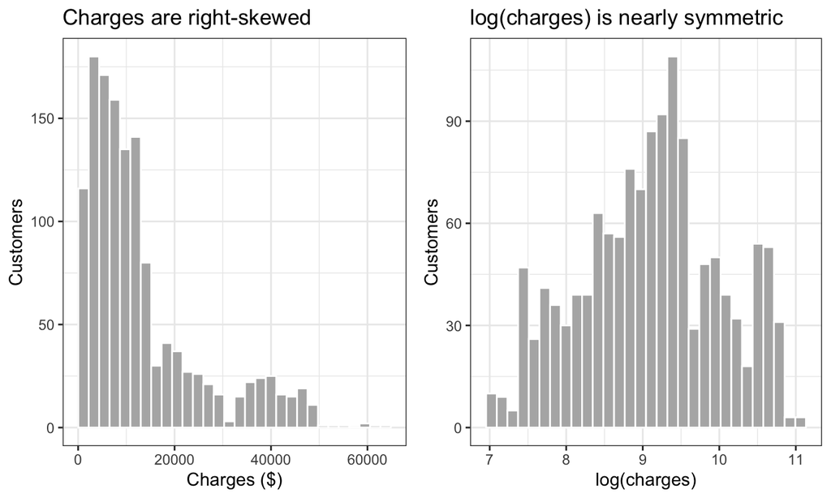

```r
p1 <- ggplot(ins, aes(x = charges)) +
  geom_histogram(bins = 30, fill = "grey70", color = "white") +
  labs(title = "Charges are right-skewed", x = "Charges ($)", y = "Customers")
p2 <- ggplot(ins, aes(x = log(charges))) +
  geom_histogram(bins = 30, fill = "grey70", color = "white") +
  labs(title = "log(charges) is nearly symmetric", x = "log(charges)", y = "Customers")
grid.arrange(p1, p2, ncol = 2)
```

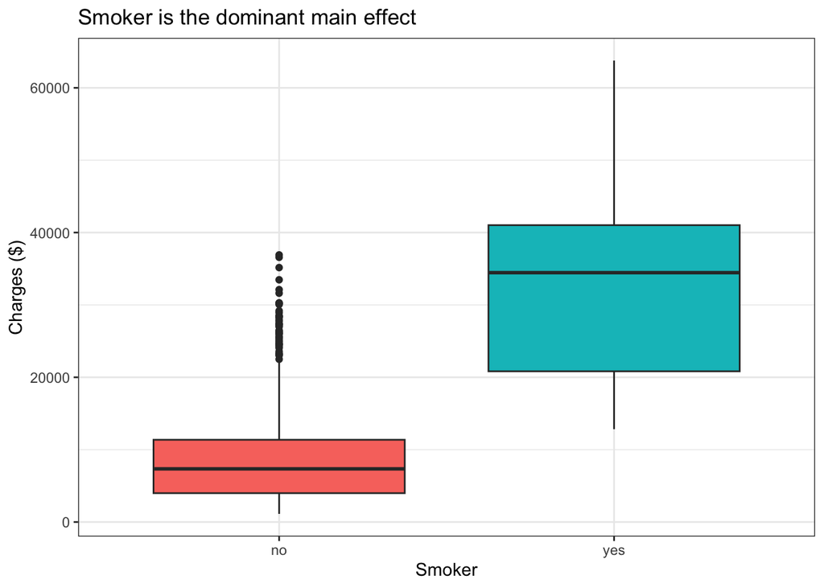

```r
ggplot(ins, aes(x = smoker, y = charges, fill = smoker)) +
  geom_boxplot() +
  guides(fill = "none") +
  labs(title = "Smoker is the dominant main effect",
       x = "Smoker", y = "Charges ($)")
```

```r
ins %>%
  group_by(smoker) %>%
  summarise(
    n = n(),
    mean = mean(charges),
    median = median(charges),
    sd = sd(charges),
    .groups = "drop"
  )
```

| smoker | n | mean | median | sd |
| --- | --- | --- | --- | --- |
| no | 1063 | 8440.66 | 7345.727 | 5992.974 |
| yes | 274 | 32050.23 | 34456.348 | 11541.547 |

### 3. Age vs charges (interaction look: age $\times$ smoker)

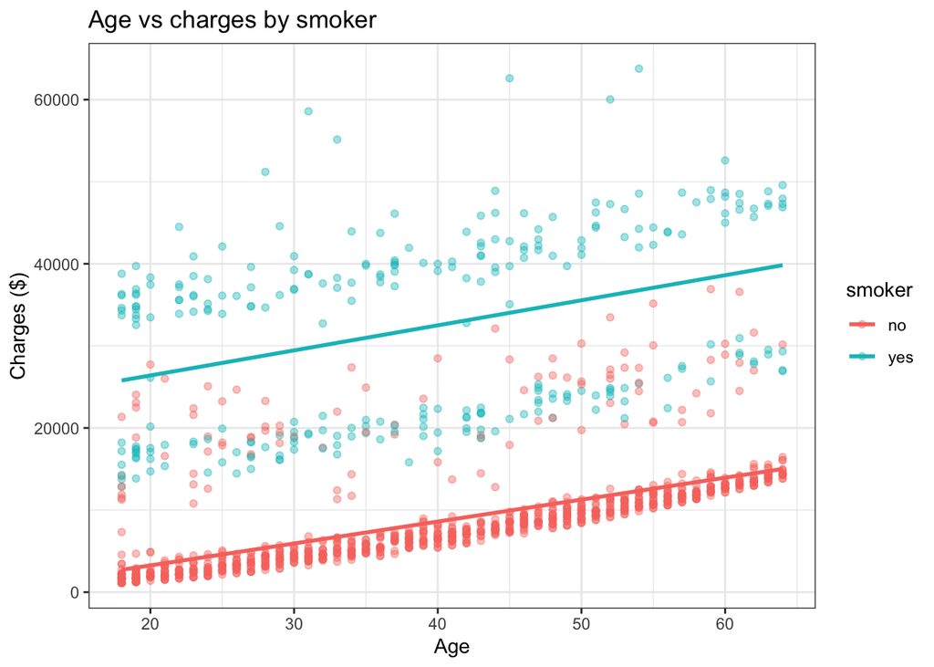

```r
ggplot(ins, aes(x = age, y = charges, color = smoker)) +
  geom_point(alpha = 0.4) +
  geom_smooth(method = "lm", se = FALSE, formula = y ~ x) +
  labs(title = "Age vs charges by smoker", x = "Age", y = "Charges ($)")
```

```r
ins %>%
  group_by(smoker) %>%
  summarise(r_age_charges = cor(age, charges), .groups = "drop")
```

| smoker | r_age_charges |
| --- | --- |
| no | 0.6274002 |
| yes | 0.3682244 |

**Answer.** Age has a steady positive slope in both groups. The correlation is stronger among non-smokers ($r = 0.63$ vs $0.37$). Smoker is a level shift of tens of thousands of dollars; age is a smaller, roughly parallel slope. Still worth `age * smoker` in the complex MLR.

### 4. Interaction: BMI $\times$ smoker

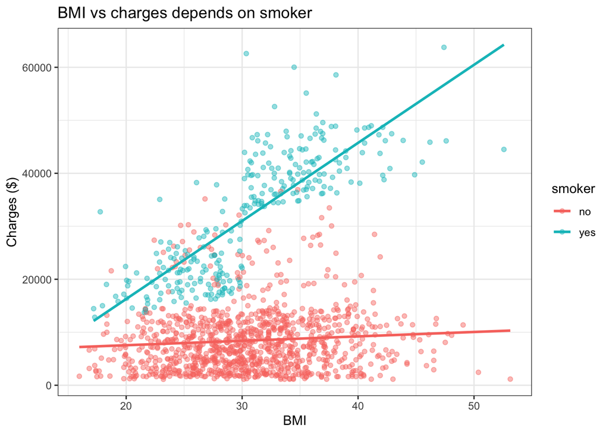

```r
ggplot(ins, aes(x = bmi, y = charges, color = smoker)) +
  geom_point(alpha = 0.45) +
  geom_smooth(method = "lm", se = FALSE, formula = y ~ x) +
  labs(title = "BMI vs charges depends on smoker",
       x = "BMI", y = "Charges ($)")
```

```r
ins %>%
  group_by(smoker) %>%
  summarise(r_bmi_charges = cor(bmi, charges), .groups = "drop")
```

| smoker | r_bmi_charges |
| --- | --- |
| no | 0.0840765 |
| yes | 0.8064806 |

Among smokers, BMI and charges correlate $r = 0.81$. Among non-smokers, $r = 0.08$. This is the strongest interaction in the file. A main-effects-only MLR averages a real slope into something that is true for neither group. Put `bmi * smoker` in the Objective 1 model, not only in the “complex” model.

### 5. Interaction: does it depend on region? (Objective 1)

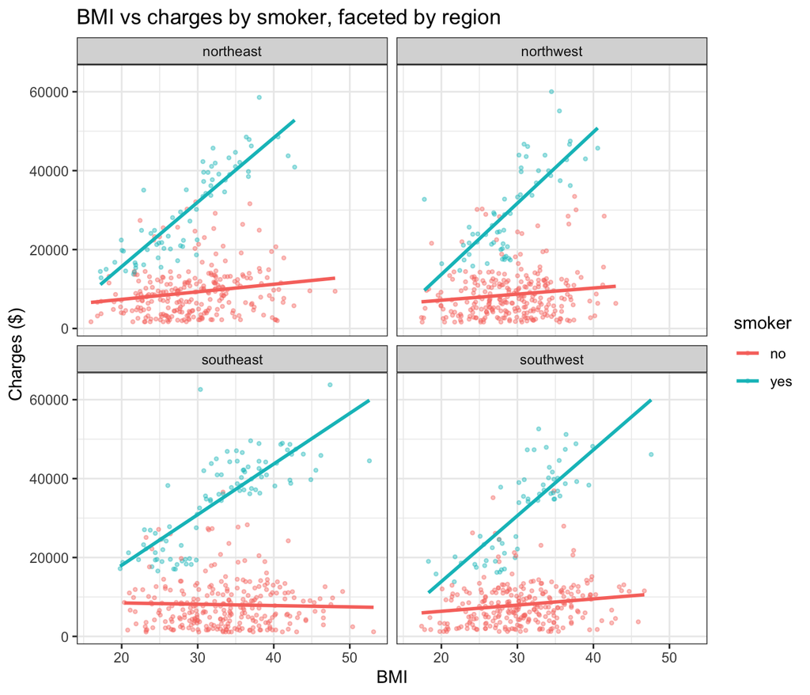

```r
ggplot(ins, aes(x = bmi, y = charges, color = smoker)) +
  geom_point(alpha = 0.4, size = 0.8) +
  geom_smooth(method = "lm", se = FALSE, formula = y ~ x) +
  facet_wrap(~region) +
  labs(title = "BMI vs charges by smoker, faceted by region",
       x = "BMI", y = "Charges ($)")
```

```r
ins %>%
  group_by(region, smoker) %>%
  summarise(n = n(), mean_charges = mean(charges), .groups = "drop") %>%
  arrange(smoker, region)
```

| region | smoker | n | mean_charges |
| --- | --- | --- | --- |
| northeast | no | 257 | 9165.532 |
| northwest | no | 266 | 8582.467 |
| southeast | no | 273 | 8032.216 |
| southwest | no | 267 | 8019.285 |
| northeast | yes | 67 | 29673.536 |
| northwest | yes | 58 | 30192.003 |
| southeast | yes | 91 | 34844.997 |
| southwest | yes | 58 | 32269.063 |

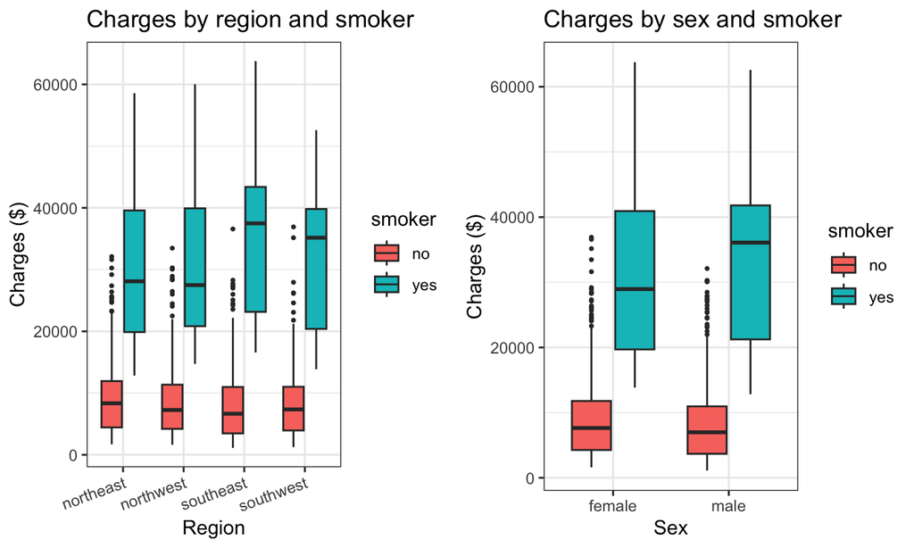

```r
p3 <- ggplot(ins, aes(x = region, y = charges, fill = smoker)) +
  geom_boxplot(outlier.size = 0.6) +
  labs(title = "Charges by region and smoker", x = "Region", y = "Charges ($)") +
  theme(axis.text.x = element_text(angle = 20, hjust = 1))
p4 <- ggplot(ins, aes(x = sex, y = charges, fill = smoker)) +
  geom_boxplot(outlier.size = 0.6) +
  labs(title = "Charges by sex and smoker", x = "Sex", y = "Charges ($)")
grid.arrange(p3, p4, ncol = 2)
```

The smoker $\times$ BMI wedge appears in every region. Region is mostly a **level shift**: Southeast smokers average about $34,845 vs about $30k in the Northeast and Northwest. Sex is small once smoker is in the picture. Objective 1 can be answered with `charges ~ age + bmi * smoker + children + region` and a `smoker * region` term if we want the prompt’s “depend on region” question in a coefficient rather than only in this plot. A three-way `bmi * smoker * region` is possible (cells 58–91) but will eat degrees of freedom; try it in Objective 2, not as the interpretability model.

### 6. Children and the numeric overview

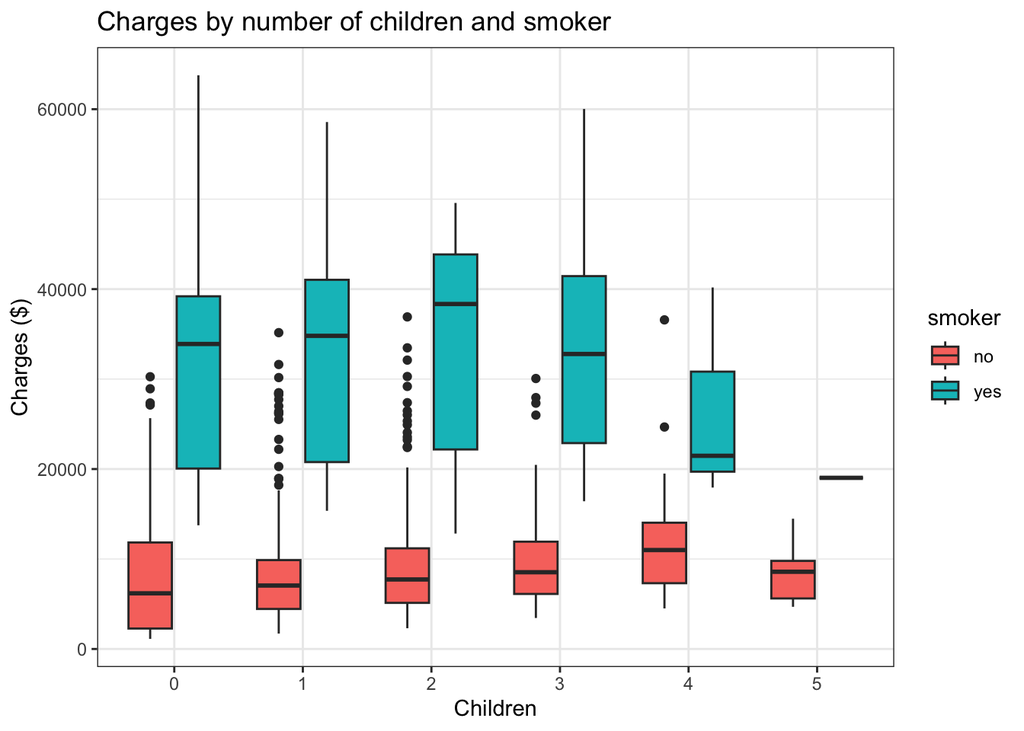

```r
ggplot(ins, aes(x = children_f, y = charges, fill = smoker)) +
  geom_boxplot() +
  labs(title = "Charges by number of children and smoker",
       x = "Children", y = "Charges ($)")
```

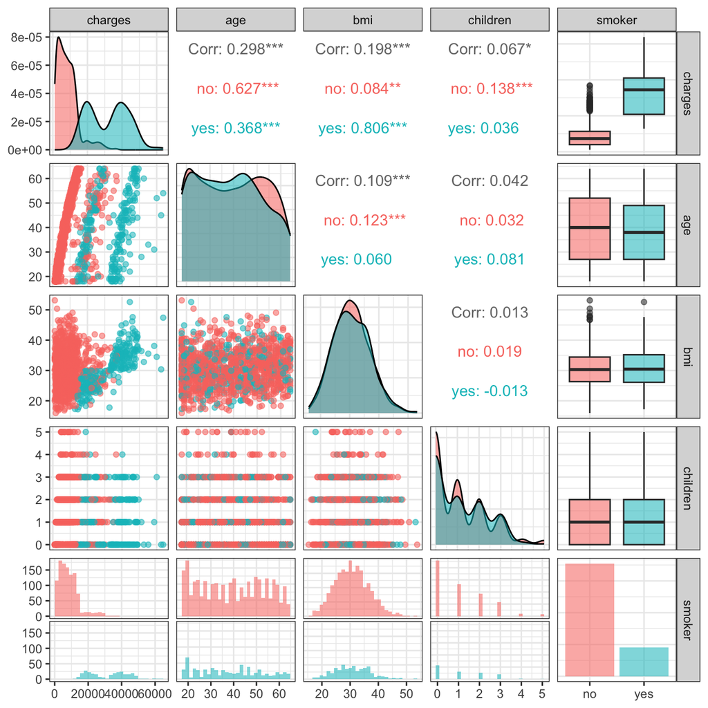

```r
ggpairs(
  ins %>% select(charges, age, bmi, children, smoker),
  mapping = aes(colour = smoker, alpha = 0.35),
  progress = FALSE
)
```

Children is a weak main effect (overall $r = 0.07$ with charges). The `ggpairs` panel is the same story in one figure: smoker separates two clouds; BMI only slopes in the smoker cloud; age slopes in both.

## Implications for the two objectives

**Objective 1 (interpret).** Lead with smoker and `bmi * smoker`. Report a CI for the smoker contrast at a fixed BMI (the interaction means the smoker gap is not a single number). Then region: either a main-effect shift or `smoker * region`. Age and children are adjustment variables. Check residuals on both `charges` and `log(charges)`. Scope of inference: these are 1337 unique customers in four US regions, not a random national sample.

**Objective 2 (predict).** A main-effects MLR will lose to anything that includes `bmi * smoker`. The complex MLR should add that interaction (and maybe `age * smoker` or a BMI polynomial for smokers). kNN / tree / RF should beat the main-effects MLR; they may **not** beat an MLR that already has the interaction. Compare models with 10-fold CV RMSE on the dollar scale.

**Next.** Fit the Objective 1 MLR. Stop expanding EDA unless a residual plot forces a new transformation.